# arete (Automated REtrieval from TExt) Automated Report

2025-09-15

## 1. Details

**FILE**: example_file.csv

**SPECIES**: example species

## 2. Data

### 2.1 - Ground truth data

| Latitude | Longitude |
| --- | --- |
| 44.34540 | 40.18947 |
| 44.58259 | 40.11512 |

### 2.2 - Model data

| Latitude | Longitude |
| --- | --- |
| 44.34540 | 40.18947 |
| 44.58259 | 40.11512 |

### 2.3 - Scatterplots

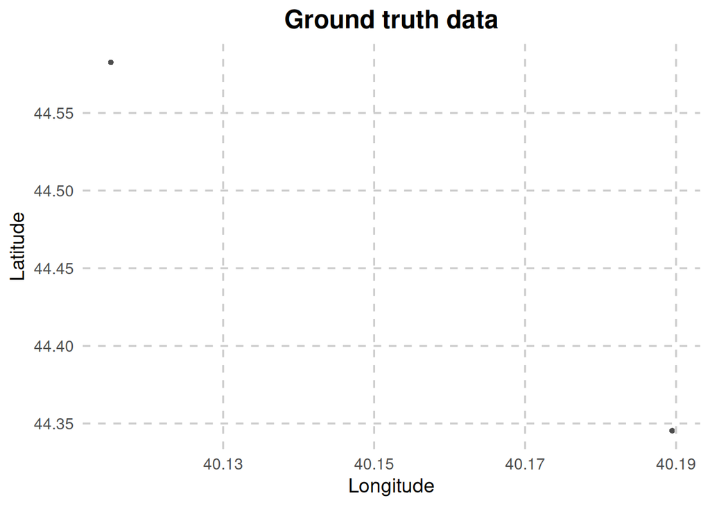

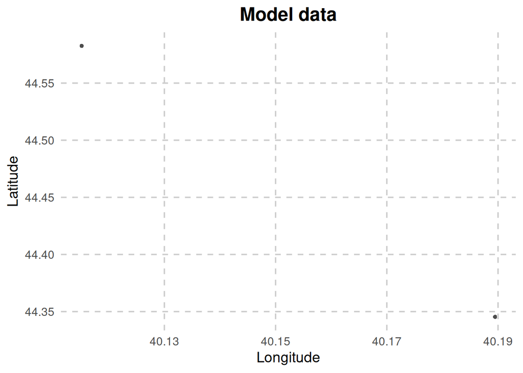

## 3. Analysis

### 3.1 - Non-intersecting species

For the above file the following NON-INTERSECTING SPECIES were found: Ground truth | Model (0, 0).

### 3.2 - Euclidean distance

Mean minimum euclidean distance is 0.

### 3.3 - Contingency table

|  | Model | Human |
| --- | --- | --- |
| Model | 1 | 1 |
| Human | 1 | 1 |

0 points unique to the model.

0 points unique to ground truth.

### 3.5 - Confusion matrix

Consider the model output our predicted values and the ground truth data as the observed values. You can then conceptualize the output as being made of TRUE POSITIVES, data points both in the model output and the ground truth; FALSE NEGATIVES, data points in the ground truth but not in the model output and FALSE POSITIVES, data points in the model output but not in the ground truth, usually called “hallucinations”.

[output not shown]

### 3.7 - Performance metrics

[output not shown]